# GISC-6323-Machine-Learning-for-Socio-Economic-and-Geo-Referenced-Data Lab02

Yalin Yang

2021-04-05

```r
library(TexMix)    ## For mapping functions
library(sp);library(maptools)
library(spdep);library(ClustGeo)

## Get neighboring state as spatial reference frame
neig.shp <- rgdal::readOGR(dsn="TXCnty2020", layer = "TXNeighbors",
                             integer64 = "allow.loss", stringsAsFactors=T)
## Get interstate layer for spatial orientation
interState.shp <- rgdal::readOGR(dsn="TXCnty2020", layer = "InterStateHwy",
                                 integer64 = "allow.loss", stringsAsFactors=T)
## Get polygons of TX counties
county.shp <- rgdal::readOGR(dsn="TXCnty2020", layer = "TXCnty2020",
                            integer64 = "allow.loss", stringsAsFactors=T)
```

## Definition of the spatial dissimilarity metric

Set the spatial tessellation of the census tracts up and prepare the contiguity space dissimilarity among the census tracts.

### spatial structure distance matrices

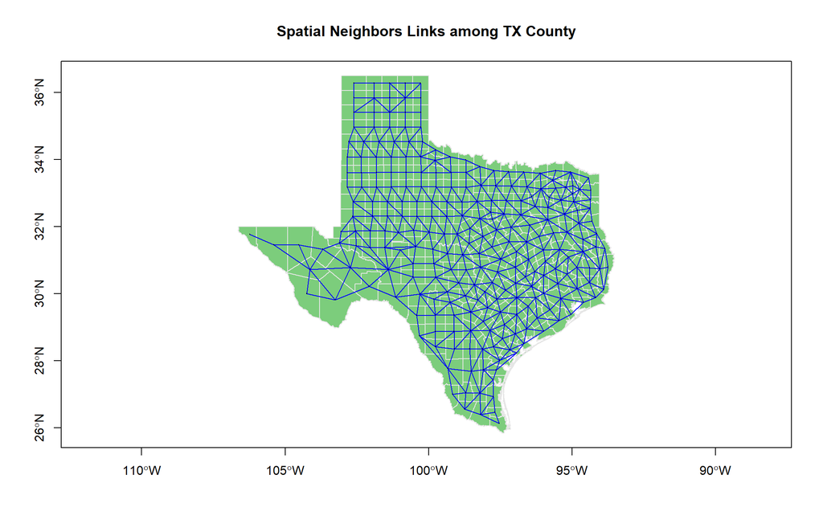

```r
##
## Exclude Loving County
##
county.shp <- county.shp[county.shp$NAME!="Loving", ]


county.bbox <- bbox(county.shp)                # county bounding box for map region
county.centroid <- coordinates(county.shp)     # Get county centroids

##
## Get spatial structure distance matrices
##
nb <- spdep::poly2nb(county.shp, queen=F)      # extract first order neighbors links
B <- spdep::nb2mat(nb, style="B")              # convert neighbor list to binary matrix
plot(county.shp, col="palegreen3", border=grey(0.9), axes=T) # map topology
plot(nb, coords=coordinates(county.shp), pch=19, cex=0.1, col="blue", add=T)
title("Spatial Neighbors Links among TX County")
```

```r
topoDist <- 1-B; diag(topoDist) <- 0          # convert into dissimilarity
topoDist <- as.dist(topoDist)                 # convert into distance object

##
## Get steps distance from topology
##
BNa <- ifelse(B==0,NA,B)                      # recode 0's to NA's
allPath <- e1071::allShortestPaths(BNa)       # calucate the shortest path among all nodes
topoDist <- as.dist(allPath$length)           # number of steps from origin to destination node
```

### spherical distance matrix

```r
sphDist <- sp::spDists(county.shp, longlat=T)   # spherical distance matrix among tracts in km
sphDist <- as.dist(sphDist)
```

## Prepare the feature similarity matrix

**[c] socio-economic:** BNEW (Percent of housing units built after 2000), BOLD (Percent of housing units built before 1960), CRIMERATE,DISTMEX,uninsured,SINGLEMOM,COLLEGEDEG,UNEMPL,INCOME,MEDVALHOME,OWNOCCPCT,MOVEPREPCT,VMDDPC

**[d] residential:** POPDENSE,MEDAGE,AGE18LESS,AGE65UP,PARTBLACK,PARTASIAN,HISPORG,BIR15TO50,NOGOODENG,DAYPOP18

```r
Vars <- county.shp@data
Vars <- transform(Vars,
  RELIGADHER = as.numeric(RELIGADHER),
  ROMVOT12 = ROMVOT12/TOTALVOT12,
  OBAVOT12 = OBAVOT12/TOTALVOT12,
  TRUMPVOT16 = TRUMPVOT16/TOTALVOT16,
  CLINTONVOT = CLINTONVOT/TOTALVOT16,
  DAYPOP18 = DAYPOP18 / NIGHTPOP18,
  POPDENSE = log(POPDENSE),
  BNEW = B2010PCT+B2000PCT,
  BOLD = B1960PCT+B1950PCT+B1940PCT+BPREPCT
)

varKeep <- c("CRIMERATE","CLINTONVOT","TRUMPVOT16","TURNOUT12","DISTMEX","MEDAGE",
             "RELIGADHER","UNINSURED","AGE18LESS","AGE65UP","PARTBLACK",
             "PARTASIAN","HISPORG","SINGLEMOM","BIR15TO50","NOGOODENG","COLLEGEDEG",
             "UNEMPL","INCOME","POPDENSE","DAYPOP18","MEDVALHOME","BNEW","BOLD",
             "OWNOCCPCT","MOVEPREPCT","VMDDPC")

xVars <- Vars[varKeep]
row.names(xVars) <- 1:nrow(xVars)
featDist <- dist(scale(xVars))
```

## Evaluate mixture of feature and spatial dissimilarity

By experiment, setting the number of clusters to 12 gives us a better result (from both homogeneity within clusters and visually interpretation )

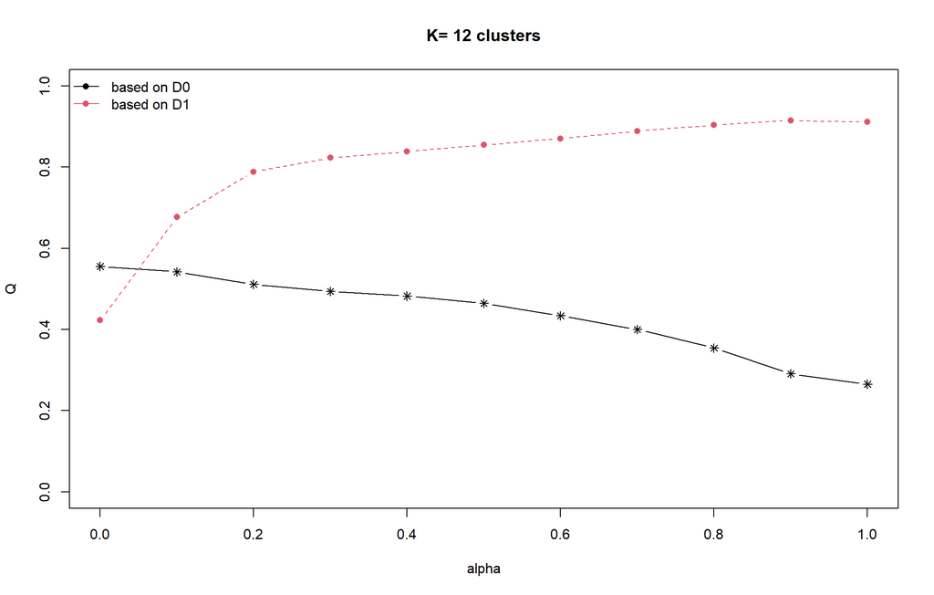

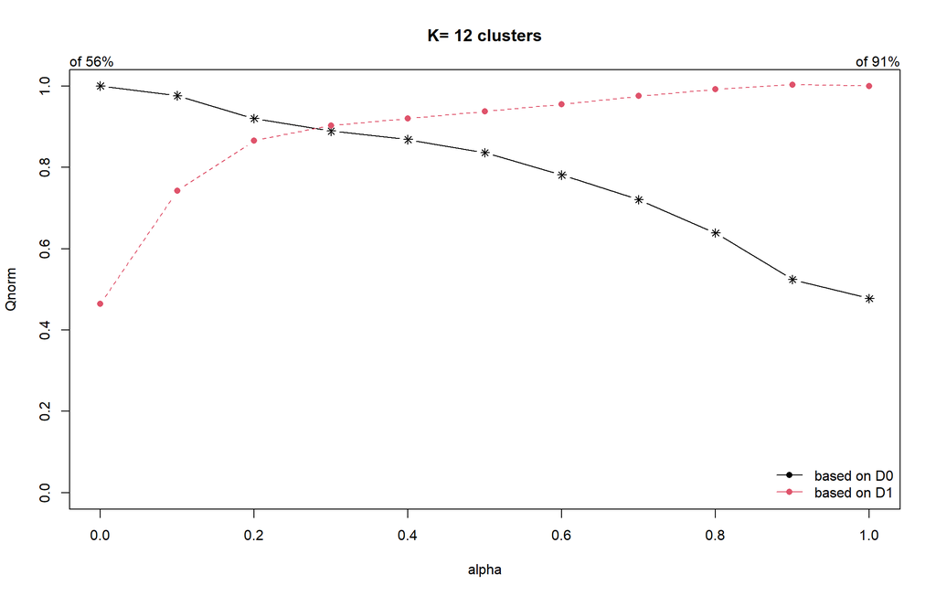

```r
set.seed(124)
K <- 12                            # Number of distinct clusters
range.alpha <- seq(0, 1, by=0.1)   # Evaluation range
cr <- choicealpha(featDist, sphDist, range.alpha, K, graph=TRUE)
```

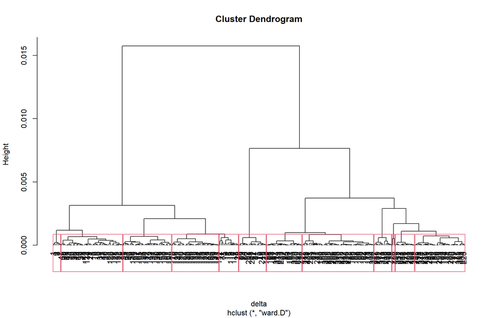

```r
tree <- hclustgeo(featDist, sphDist, alpha=0.3)
plot(tree, hang=-1)
rect.hclust(tree, k=K)
```

```r
neighClus <- as.factor(cutree(tree, K))        # Determine cluster membership
table(neighClus)                               # number of tracts in each cluster
```

```
## neighClus
##  1  2  3  4  5  6  7  8  9 10 11 12
##  5 12 38 17 30 29 31  2 22 11 44 12
```

## Check the value of variables from each cluster

Based on the box plot, we could generalize the characteristics for each cluster we discovered. Task cluster 1 as an example, it has a high % of Hispanic groups, a high % of uninsured, a high % of young people, a high % of people who do not good at English, and most of the residents support Democrats.

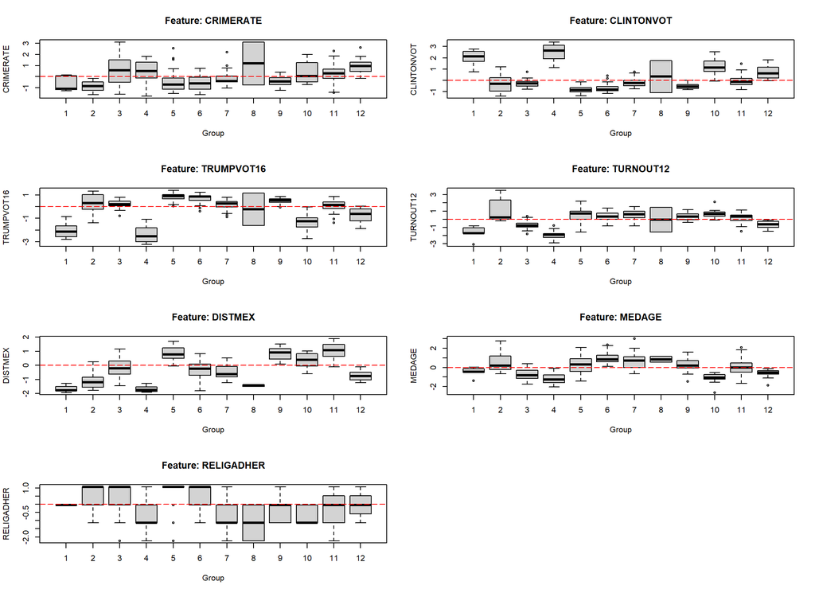

```r
plotBoxesByFactor(xVars[,1:7], neighClus, ncol=2, zTrans=T, varwidth=F)
```

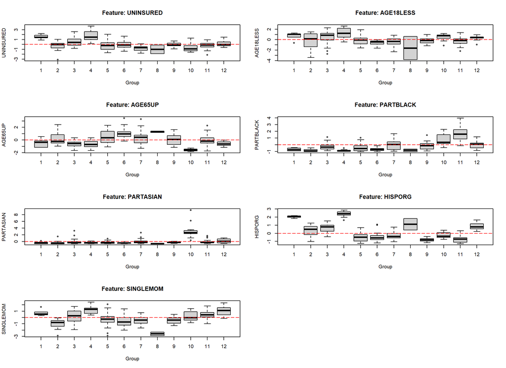

```r
plotBoxesByFactor(xVars[,8:14], neighClus, ncol=2, zTrans=T, varwidth=F)
```

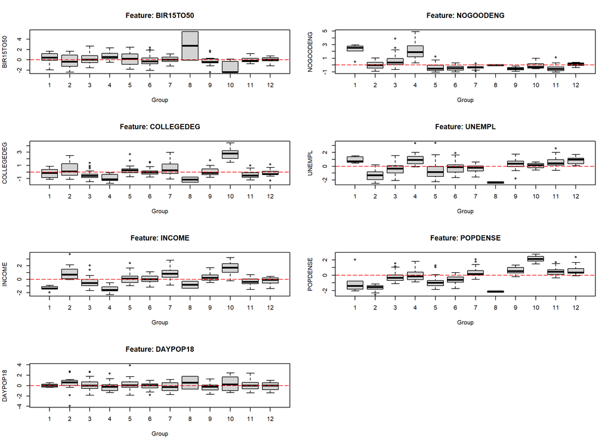

```r
plotBoxesByFactor(xVars[,15:21], neighClus, ncol=2, zTrans=T, varwidth=F)
```

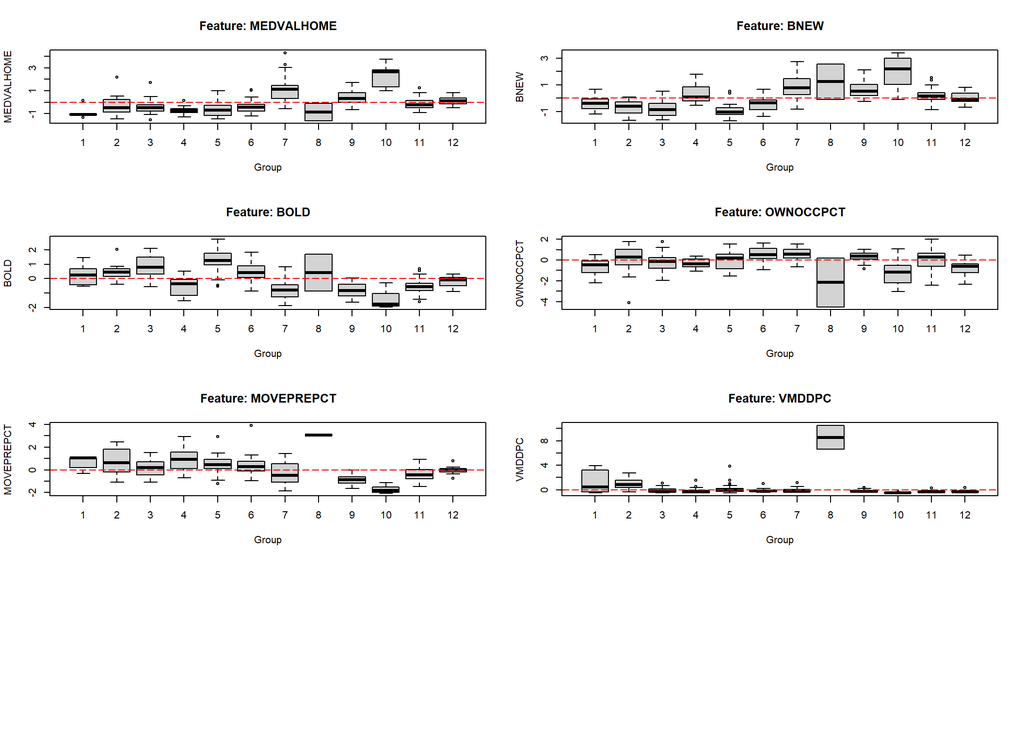

```r
plotBoxesByFactor(xVars[,22:27], neighClus, ncol=2, zTrans=T, varwidth=F)
```

## Map Results

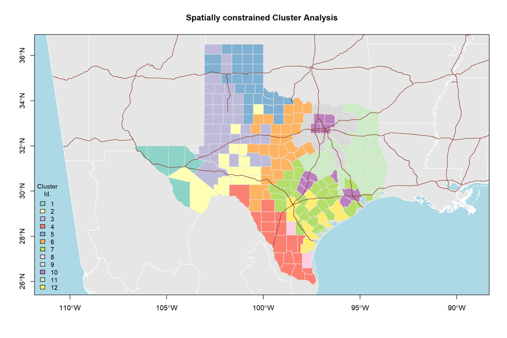

```r
plot(neig.shp, axes=T, col=grey(0.9),                       # first background (only for final maps)
     border="white", bg="lightblue",
     xlim=county.bbox[1,], ylim=county.bbox[2,])

mapColorQual(neighClus, county.shp,
             map.title ="Spatially constrained Cluster Analysis",
             legend.title="Cluster\nId.", legend.cex=0.9, add=T)

plot(interState.shp, col="tomato4", lwd=1, add=T)             # insert road network for orientation
```